# Plotting_with_Python

Back to Blog

## Creating Plots Using a Script and as an Object

#### Here's a quick overview at basic plotting with Python. For this demonstration I make use of iPython notebook.

```python
# We import the matplotlib package. This is the main package to plot in Python. The plotting package that comes with Python
# does not give you all the capability as Matplotlib does.
import matplotlib.pyplot as plt
%matplotlib inline
# We import a numerical python package called Numpy
import numpy as np
```

```python
# Now we generate some numbers:
x = np.linspace(0,10)
```

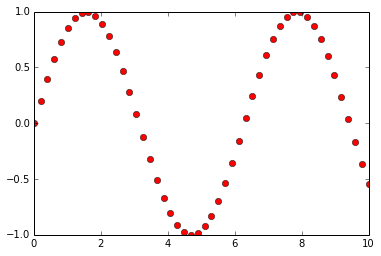

```python
# We define a sin function:
y = np.sin(x)

# Next we begin by the plot. There are two ways to plot in python. One involves a simple script while the other makes use of
# object oriented programming. I will begin with an example of simple script. However, I would insist that you begin to plot
# in the object-oriented way as it is more generic and easy to modify.

# We begin with the plot command:
plt.plot(x, y, 'ro')
plt.show()
```

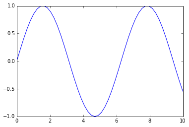

```python
#Next, we look at linestyles, labels, and legends.

plt.plot(x, y, 'b-')
```

The line style used here is that of a solid line with color blue. Here are some different types:

- solid line: '-'
- dash line: '--'
- dash-dot: '-.'
- dotted line : ':'
- filled circle: 'o'
- triangles: '^'
- plus: '+'
- star: '*'

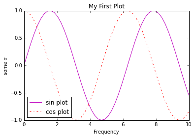

```python
# Create two plots
plt.plot(x, y, 'm-', label = 'sin plot')
plt.plot(x, np.cos(x), 'r-.', label = 'cos plot')
# Add x, y labels, and a title
plt.xlabel('Frequency')
plt.ylabel('some $\pi$')
plt.title("My First Plot")
plt.legend(numpoints = 1, loc=3)
```

Alright, so we did a lot here. We first created a sin plot and labeled is "sin plot". The plot also made use of the magenta color with a solid line. Then we did the same with the cos plot but used the red color for a dash-dot line. Note that we do not need to do "oplot" as we do in IDL. Python is clever enough to understand that the second line is trying to overplot.

Notice that each plotting command now has a label associated with it. This is the label that we pull when we call the legend() function. So, this is how legends are created in a plot.

Next, we created x and y labels. Note that in the y-label we made use of Latex command. Python natively takes Latex commands in labels. Then we created the title of the plot. Finally, we called the legend() function to create the legend in the plot. We use the numpoints argument in legend() to make sure Python only plotting one legend per plot. Try to run it without it. We then made use of location (loc) to set the position of the legend box inside the plotting window. loc ranges from 1 through 8. We can do a little more:

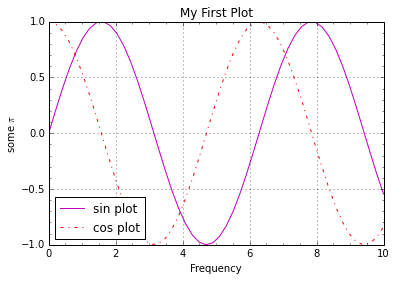

```python
# Create two plots
plt.plot(x, y, 'm-', label = 'sin plot')
plt.plot(x, np.cos(x), 'r-.', label = 'cos plot')
# Add x, y labels, and a title
plt.xlabel('Frequency')
plt.ylabel('some $\pi$')
plt.title("My First Plot")
plt.minorticks_on()               # <--- add minor ticks
plt.grid(True)                    # <--- add a grid
plt.legend(numpoints = 1, loc=3)
```

# Creating Plots using Object Oriented Programming

All figures reside inside the figure object. To plot a figure we create a figure object. It is done in the following way:

```python
fig = plt.figure()
```

plt.figure has various options including figsize which sets the figure size and aspect ratio. It also takes argument such as plt.figure(2) which calls the second figure if two or more are created.

Once the object fig has been created we need to set axes to it. This is done in the following way:

```python
ax1 = fig.add_axes([0.09,0.49,0.40,0.48])
```

```python
ax1.plot(x, y, 'b-')
```